# Visualisation of DESeq2 results

**Libraries needed:**

```r
if (!require("librarian")) install.packages("librarian")
# data
librarian::shelf(tibble, DESeq2, stringr, matrixStats, limma)
# graphics
librarian::shelf(ggplot2, ggthemes, ggtext, ggrepel)
# convenience
library(here); setwd(here())
```

**Path to definitive images (outside repo):**

```r
figdir <- paste0(c(head(str_split(getwd(),'/')[[1]],-1),
                   paste0(tail(str_split(getwd(),'/')[[1]],1), '_figures')),
                 collapse='/')
dir.create(figdir, showWarnings = FALSE)
```

# RNAseq results visualisation: Principal Components Analysis

## 1 Using the raw counts

```r
# get the data (fresh session)
targets <- readRDS('output/targets.RDS')
tpmNormalisedCounts <- readRDS('output/tpmNormalisedCounts.RDS')
normalisedCounts <- readRDS('output/normalisedCounts.RDS')
rawCounts <- readRDS('output/rawCounts.RDS')
```

Let us see what the variance looks like in `rawCounts`:

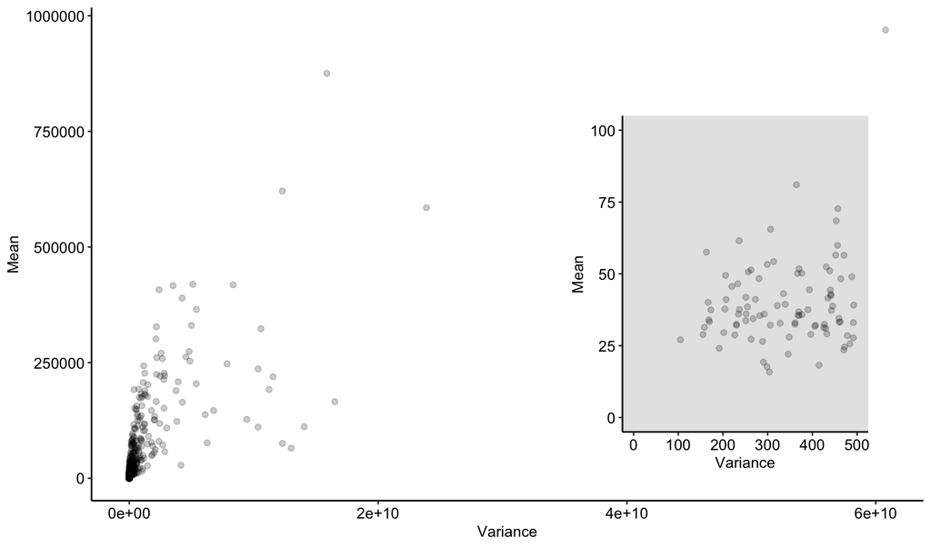

```r
var_rawCounts <- rowVars(as.matrix(rawCounts), rm.na=TRUE)
var_rawCounts <- var_rawCounts [ var_rawCounts < max(var_rawCounts) ]
avg_rawCounts <- rowMeans(as.matrix(rawCounts))
avg_rawCounts <- avg_rawCounts [ avg_rawCounts < max(avg_rawCounts) ]
df <- data.frame(Variance=var_rawCounts, Mean=avg_rawCounts)
p1 <- ggplot(df, aes(x=Variance, y=Mean)) +
  geom_point(alpha=0.2)
p2 <- ggplot(df, aes(x=Variance, y=Mean)) +
  geom_point(alpha=0.2) + xlim(0, 500) + ylim(0, 100) +
  theme(panel.background = element_rect(fill='grey90'))
p1 + annotation_custom(ggplotGrob(p2),
                       xmin=3.5e10, xmax=6e10,
                       ymin=1e2, ymax=8e5)
```

It does not look like it is necessary to filter for variance, so we can calculate the principal components straight away:

```r
pca <- prcomp(t(rawCounts), center=TRUE, scale=TRUE)
scores <- data.frame(targets$sampleIDs, pca$x[,1:2])
summary(pca)
```

```
## Importance of components:
##                            PC1     PC2     PC3      PC4     PC5      PC6
## Standard deviation     79.2341 38.9825 25.3020 19.31988 15.6875 14.47398
## Proportion of Variance  0.6276  0.1519  0.0640  0.03731  0.0246  0.02094
## Cumulative Proportion   0.6276  0.7795  0.8435  0.88085  0.9054  0.92639
##                             PC7      PC8     PC9    PC10    PC11    PC12
## Standard deviation     13.44660 11.94091 9.17122 8.76511 7.76814 7.63650
## Proportion of Variance  0.01808  0.01425 0.00841 0.00768 0.00603 0.00583
## Cumulative Proportion   0.94447  0.95872 0.96713 0.97481 0.98085 0.98668
##                           PC13    PC14    PC15    PC16      PC17
## Standard deviation     7.02791 5.95460 5.26467 4.55090 7.197e-14
## Proportion of Variance 0.00494 0.00354 0.00277 0.00207 0.000e+00
## Cumulative Proportion  0.99161 0.99516 0.99793 1.00000 1.000e+00
```

Plot:

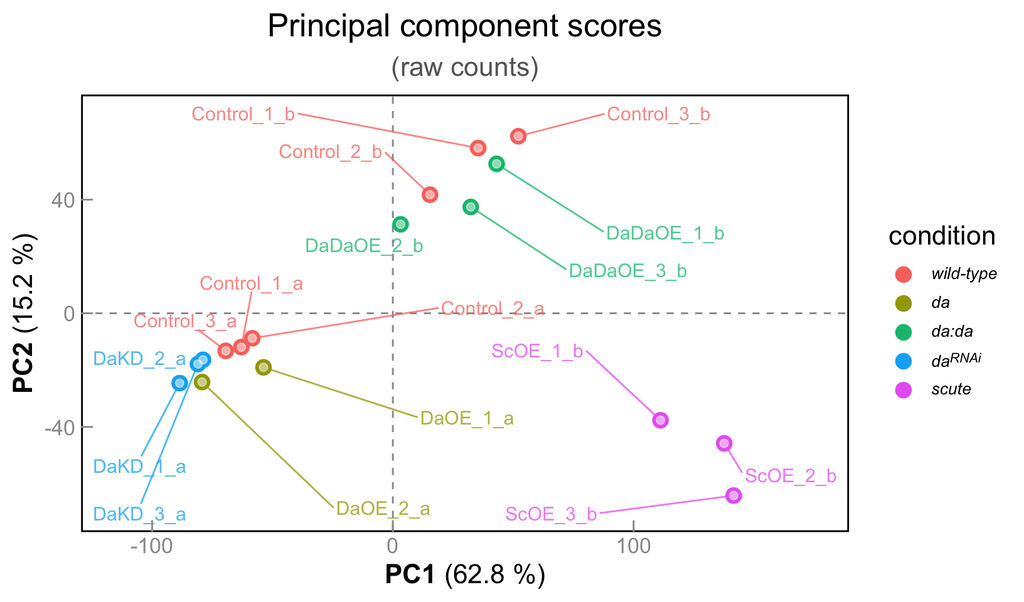

```r
xtitle <- paste0('**PC1** (', round(summary(pca)$importance['Proportion of Variance','PC1']*100,1), ' %)')
ytitle <- paste0('**PC2** (', round(summary(pca)$importance['Proportion of Variance','PC2']*100,1), ' %)')
ptitle <- 'Principal component scores'
stitle <- '(raw counts)'

ggplot(scores,
       aes(x = PC1, y = PC2,
           label=factor(targets$sampleIDs),
           colour=factor(targets$condition_md) )
       ) +
  # data
  geom_vline(xintercept=0, linetype='dashed', colour='grey60', linewidth=0.5) +
  geom_hline(yintercept=0, linetype='dashed', colour='grey60', linewidth=0.5) +
  geom_point(size=4) +
  geom_point(size=2, colour='white', alpha=0.5) +
  geom_text_repel(size=4, alpha=0.75,
                  max.overlaps=Inf,
                  seed=42,
                  force=1.2, force_pull=-0.02,
                  box.padding=0.5, point.padding=0.5) +
  lims(x= c(-115, 175), y = c(-70, 70)) +
  # decorations
  theme_minimal(base_size=16) +
  labs(x=xtitle,
       y=ytitle,
       title=ptitle,
       subtitle=stitle) +
  scale_colour_discrete(name="condition") +
  theme(legend.text = element_markdown(size=10),
        axis.title.x = element_markdown(),
        axis.title.y = element_markdown(),
        plot.title = element_text(hjust=0.5),
        plot.subtitle = element_text(hjust=0.5, color="grey40"),
        axis.text.x = element_text(color="grey60"),
        axis.text.y = element_text(color="grey60"),
        axis.ticks.x = element_line(linewidth=0.5, linetype = "solid", color="grey60"),
        axis.ticks.y = element_line(linewidth=0.5, linetype = "solid", color="grey60"),
        axis.ticks.length=unit(-0.25, "cm"),
        panel.border = element_rect(linewidth=1, linetype = "solid", fill = NA),
        panel.grid = element_blank())
```

## 2 Using normalised counts

Let’s do this again with the `normalisedCounts` and the `tpmNormalisedCounts`:

```r
pca <- prcomp(t(normalisedCounts), center=TRUE, scale=TRUE)
scores <- data.frame(targets$sampleIDs, pca$x[,1:2])
summary(pca)
```

```
## Importance of components:
##                            PC1     PC2      PC3    PC4      PC5      PC6
## Standard deviation     69.2460 42.5572 31.55761 25.302 17.42507 16.66717
## Proportion of Variance  0.4794  0.1811  0.09956  0.064  0.03035  0.02777
## Cumulative Proportion   0.4794  0.6604  0.75997  0.824  0.85433  0.88210
##                             PC7      PC8      PC9     PC10    PC11   PC12
## Standard deviation     15.27681 14.15858 12.32032 12.17122 10.2984 9.4905
## Proportion of Variance  0.02333  0.02004  0.01517  0.01481  0.0106 0.0090
## Cumulative Proportion   0.90543  0.92547  0.94064  0.95545  0.9660 0.9751
##                          PC13    PC14    PC15    PC16     PC17
## Standard deviation     8.8330 8.06978 7.65693 6.90762 6.08e-14
## Proportion of Variance 0.0078 0.00651 0.00586 0.00477 0.00e+00
## Cumulative Proportion  0.9829 0.98937 0.99523 1.00000 1.00e+00
```

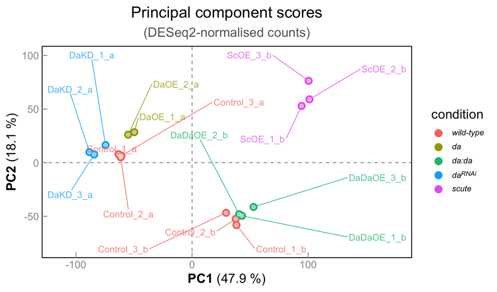

```r
xtitle <- paste0('**PC1** (', round(summary(pca)$importance['Proportion of Variance','PC1']*100,1), ' %)')
ytitle <- paste0('**PC2** (', round(summary(pca)$importance['Proportion of Variance','PC2']*100,1), ' %)')
ptitle <- 'Principal component scores'
stitle <- '(DESeq2-normalised counts)'

ggplot(scores,
       aes(x = PC1, y = PC2,
           label=factor(targets$sampleIDs),
           colour=factor(targets$condition_md) )
       ) +
  # data
  geom_vline(xintercept=0, linetype='dashed', colour='grey60', linewidth=0.5) +
  geom_hline(yintercept=0, linetype='dashed', colour='grey60', linewidth=0.5) +
  geom_point(size=4) +
  geom_point(size=2, colour='white', alpha=0.5) +
  geom_text_repel(size=4, alpha=0.75,
                  max.overlaps=Inf,
                  seed=42,
                  force=1.2, force_pull=-0.02,
                  box.padding=0.5, point.padding=0.5) +
  lims(x= c(-115, 175), y = c(-80, 100)) +
  # decorations
  theme_minimal(base_size=16) +
  labs(x=xtitle,
       y=ytitle,
       title=ptitle,
       subtitle=stitle) +
  scale_colour_discrete(name="condition") +
  theme(legend.text = element_markdown(size=10),
        axis.title.x = element_markdown(),
        axis.title.y = element_markdown(),
        plot.title = element_text(hjust=0.5),
        plot.subtitle = element_text(hjust=0.5, color="grey40"),
        axis.text.x = element_text(color="grey60"),
        axis.text.y = element_text(color="grey60"),
        axis.ticks.x = element_line(linewidth=0.5, linetype = "solid", color="grey60"),
        axis.ticks.y = element_line(linewidth=0.5, linetype = "solid", color="grey60"),
        axis.ticks.length=unit(-0.25, "cm"),
        panel.border = element_rect(linewidth=1, linetype = "solid", fill = NA),
        panel.grid = element_blank())
```

```r
pca <- prcomp(t(tpmNormalisedCounts), center=TRUE, scale=TRUE)
scores <- data.frame(targets$sampleIDs, pca$x[,1:2])
summary(pca)
```

```
## Importance of components:
##                            PC1     PC2     PC3      PC4      PC5      PC6
## Standard deviation     75.5875 40.1057 27.5180 24.63338 15.94840 15.38309
## Proportion of Variance  0.5712  0.1608  0.0757  0.06066  0.02543  0.02366
## Cumulative Proportion   0.5712  0.7320  0.8077  0.86834  0.89376  0.91742
##                             PC7      PC8      PC9    PC10    PC11    PC12
## Standard deviation     13.53897 11.58328 10.19436 9.30652 8.66451 8.01989
## Proportion of Variance  0.01832  0.01341  0.01039 0.00866 0.00751 0.00643
## Cumulative Proportion   0.93575  0.94916  0.95955 0.96821 0.97571 0.98214
##                          PC13    PC14    PC15    PC16      PC17
## Standard deviation     7.4172 6.79135 6.42430 6.01847 8.089e-14
## Proportion of Variance 0.0055 0.00461 0.00413 0.00362 0.000e+00
## Cumulative Proportion  0.9876 0.99225 0.99638 1.00000 1.000e+00
```

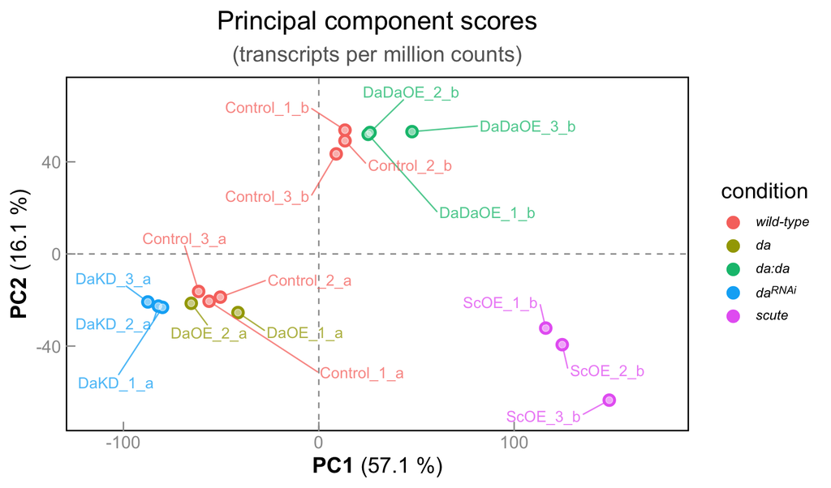

```r
xtitle <- paste0('**PC1** (', round(summary(pca)$importance['Proportion of Variance','PC1']*100,1), ' %)')
ytitle <- paste0('**PC2** (', round(summary(pca)$importance['Proportion of Variance','PC2']*100,1), ' %)')
ptitle <- 'Principal component scores'
stitle <- '(transcripts per million counts)'

ggplot(scores,
       aes(x = PC1, y = PC2,
           label=factor(targets$sampleIDs),
           colour=factor(targets$condition_md) )
       ) +
  # data
  geom_vline(xintercept=0, linetype='dashed', colour='grey60', linewidth=0.5) +
  geom_hline(yintercept=0, linetype='dashed', colour='grey60', linewidth=0.5) +
  geom_point(size=4) +
  geom_point(size=2, colour='white', alpha=0.5) +
  geom_text_repel(size=4, alpha=0.75,
                  max.overlaps=Inf,
                  seed=42,
                  force=1.2, force_pull=-0.02,
                  box.padding=0.5, point.padding=0.5) +
  lims(x= c(-115, 175), y = c(-70, 70)) +
  # decorations
  theme_minimal(base_size=16) +
  labs(x=xtitle,
       y=ytitle,
       title=ptitle,
       subtitle=stitle) +
  scale_colour_discrete(name="condition") +
  theme(legend.text = element_markdown(size=10),
        axis.title.x = element_markdown(),
        axis.title.y = element_markdown(),
        plot.title = element_text(hjust=0.5),
        plot.subtitle = element_text(hjust=0.5, color="grey40"),
        axis.text.x = element_text(color="grey60"),
        axis.text.y = element_text(color="grey60"),
        axis.ticks.x = element_line(linewidth=0.5, linetype = "solid", color="grey60"),
        axis.ticks.y = element_line(linewidth=0.5, linetype = "solid", color="grey60"),
        axis.ticks.length=unit(-0.25, "cm"),
        panel.border = element_rect(linewidth=1, linetype = "solid", fill = NA),
        panel.grid = element_blank())
```

The differences between these 3 are minimal, and the groupings are clearly dominated by biological replicates and batches.

## 3 Using variance-stabilising transformed-counts

Now with the *variance-stabilising*-transformed counts (pseudocounts):

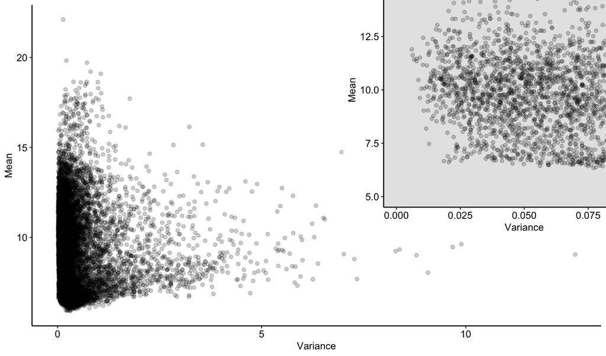

```r
vsd <- readRDS('output/vst_pseudocounts.RDS')
# remove rows with very little variability
# vsd_pca <- assay(vsd)[
#   rowSums(rawCounts[-1] != rawCounts[[2]], na.rm = TRUE) != 0, ]
var_vsd <- rowVars(assay(vsd), rm.na=TRUE)
#var_rawCounts <- var_rawCounts [ var_rawCounts < max(var_rawCounts) ]
avg_vsd <- rowMeans(assay(vsd))
#avg_rawCounts <- avg_rawCounts [ avg_rawCounts < max(avg_rawCounts) ]
df <- data.frame(Variance=var_vsd, Mean=avg_vsd)
p1 <- ggplot(df, aes(x=Variance, y=Mean)) +
  geom_point(alpha=0.2)
p2 <- ggplot(df, aes(x=Variance, y=Mean)) +
  geom_point(alpha=0.2) + xlim(0,0.1) + ylim(5,15) +
  theme(panel.background = element_rect(fill='grey90'))
p1 + annotation_custom(ggplotGrob(p2),
                       xmin=7, xmax=15,
                       ymin=10, ymax=25)
```

Some genes have very low variance (which is the whole point of the `vst` transformation), but none of them are zero. There seems to be little point in drawing an arbitrary threshold, so I move on with this.

### Pseudocounts *without* batch correction

```r
pca <- prcomp(t(assay(vsd)), center=TRUE) # scaling no longer necessary, as these are log-transformed
scores <- data.frame(targets$sampleIDs, pca$x[,1:2])
summary(pca)
```

```
## Importance of components:
##                            PC1     PC2     PC3      PC4     PC5     PC6    PC7
## Standard deviation     54.3245 28.5551 23.3508 15.44251 9.92274 8.55334 7.8677
## Proportion of Variance  0.5911  0.1633  0.1092  0.04777 0.01972 0.01465 0.0124
## Cumulative Proportion   0.5911  0.7544  0.8637  0.91143 0.93115 0.94581 0.9582
##                            PC8     PC9    PC10    PC11    PC12    PC13    PC14
## Standard deviation     6.32970 6.25509 5.91869 4.90292 4.52711 4.04674 3.74448
## Proportion of Variance 0.00803 0.00784 0.00702 0.00481 0.00411 0.00328 0.00281
## Cumulative Proportion  0.96623 0.97407 0.98108 0.98590 0.99000 0.99328 0.99609
##                           PC15    PC16      PC17
## Standard deviation     3.36453 2.86123 1.136e-13
## Proportion of Variance 0.00227 0.00164 0.000e+00
## Cumulative Proportion  0.99836 1.00000 1.000e+00
```

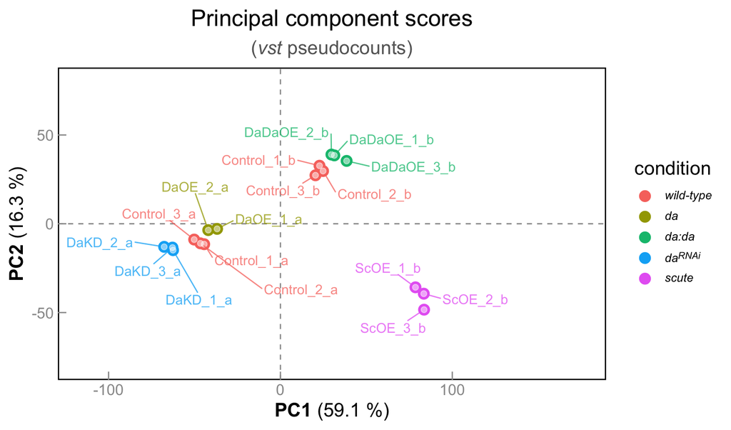

```r
xtitle <- paste0('**PC1** (', round(summary(pca)$importance['Proportion of Variance','PC1']*100,1), ' %)')
ytitle <- paste0('**PC2** (', round(summary(pca)$importance['Proportion of Variance','PC2']*100,1), ' %)')
ptitle <- 'Principal component scores'
stitle <- '(*vst* pseudocounts)'

ggplot(scores,
       aes(x = PC1, y = PC2,
           label=factor(targets$sampleIDs),
           colour=factor(targets$condition_md) )
       ) +
  # data
  geom_vline(xintercept=0, linetype='dashed', colour='grey60', linewidth=0.5) +
  geom_hline(yintercept=0, linetype='dashed', colour='grey60', linewidth=0.5) +
  geom_point(size=4) +
  geom_point(size=2, colour='white', alpha=0.5) +
  geom_text_repel(size=4, alpha=0.75,
                  max.overlaps=Inf,
                  seed=42,
                  force=1.2, force_pull=-0.02,
                  box.padding=0.5, point.padding=0.5) +
  lims(x= c(-115, 175), y = c(-80, 80)) +
  # decorations
  theme_minimal(base_size=16) +
  labs(x=xtitle,
       y=ytitle,
       title=ptitle,
       subtitle=stitle) +
  scale_colour_discrete(name="condition") +
  theme(legend.text = element_markdown(size=10),
        axis.title.x = element_markdown(),
        axis.title.y = element_markdown(),
        plot.title = element_text(hjust=0.5),
        plot.subtitle = element_markdown(hjust=0.5, color="grey40"),
        axis.text.x = element_text(color="grey60"),
        axis.text.y = element_text(color="grey60"),
        axis.ticks.x = element_line(linewidth=0.5, linetype = "solid", color="grey60"),
        axis.ticks.y = element_line(linewidth=0.5, linetype = "solid", color="grey60"),
        axis.ticks.length=unit(-0.25, "cm"),
        panel.border = element_rect(linewidth=1, linetype = "solid", fill = NA),
        panel.grid = element_blank())
```

```r
ggsave('PCA_vsd.pdf', plot = last_plot(), device = 'pdf',
       path = figdir, dpi = 300)
ggsave('PCA_vsd.svg', plot = last_plot(), device = 'svg',
       path = figdir, dpi = 300)
ggsave('PCA_vsd.png', plot = last_plot(), device = png,
       path = figdir, dpi = 300)
```

Again, very similar to the other 3, which is (marginally) reassuring.

### Pseudocounts *with* batch correction

Now, if we do the same with the **batch-corrected** VS-transformed data:

```r
vsd_bcorr <- readRDS('output/vst_pseudocounts_batchCorrected.RDS')
pca <- prcomp(t(assay(vsd_bcorr)), center=TRUE)
scores <- data.frame(targets$sampleIDs, pca$x[,1:2])
summary(pca)
```

```
## Importance of components:
##                            PC1     PC2     PC3      PC4     PC5     PC6     PC7
## Standard deviation     39.1456 24.4895 18.9568 11.32089 8.58119 7.89523 6.40586
## Proportion of Variance  0.5159  0.2019  0.1210  0.04315 0.02479 0.02099 0.01381
## Cumulative Proportion   0.5159  0.7178  0.8388  0.88193 0.90672 0.92771 0.94152
##                            PC8     PC9    PC10    PC11    PC12    PC13    PC14
## Standard deviation     6.26018 6.16341 5.00549 4.60899 4.05518 3.74473 3.38970
## Proportion of Variance 0.01319 0.01279 0.00844 0.00715 0.00554 0.00472 0.00387
## Cumulative Proportion  0.95471 0.96750 0.97594 0.98309 0.98863 0.99335 0.99722
##                           PC15      PC16      PC17
## Standard deviation     2.87613 5.366e-14 3.246e-14
## Proportion of Variance 0.00278 0.000e+00 0.000e+00
## Cumulative Proportion  1.00000 1.000e+00 1.000e+00
```

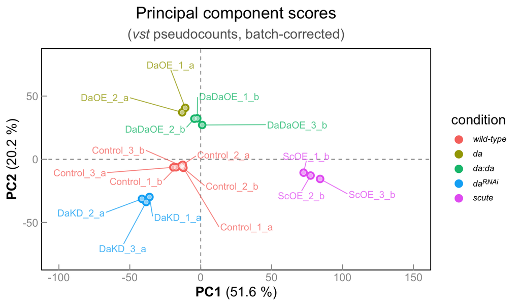

```r
xtitle <- paste0('**PC1** (', round(summary(pca)$importance['Proportion of Variance','PC1']*100,1), ' %)')
ytitle <- paste0('**PC2** (', round(summary(pca)$importance['Proportion of Variance','PC2']*100,1), ' %)')
ptitle <- 'Principal component scores'
stitle <- '(*vst* pseudocounts, batch-corrected)'

ggplot(scores,
       aes(x = PC1, y = PC2,
           label=factor(targets$sampleIDs),
           colour=factor(targets$condition_md) )
       ) +
  # data
  geom_vline(xintercept=0, linetype='dashed', colour='grey60', linewidth=0.5) +
  geom_hline(yintercept=0, linetype='dashed', colour='grey60', linewidth=0.5) +
  geom_point(size=4) +
  geom_point(size=2, colour='white', alpha=0.5) +
  geom_text_repel(size=4, alpha=0.75,
                  max.overlaps=Inf,
                  seed=42,
                  force=0.3, force_pull=1,
                  box.padding=1, point.padding=0.5) +
  lims(x= c(-100, 150), y = c(-80, 80)) +
  # decorations
  theme_minimal(base_size=16) +
  labs(x=xtitle,
       y=ytitle,
       title=ptitle,
       subtitle=stitle) +
  scale_colour_discrete(name="condition") +
  theme(legend.text = element_markdown(size=10),
        axis.title.x = element_markdown(),
        axis.title.y = element_markdown(),
        plot.title = element_text(hjust=0.5),
        plot.subtitle = element_markdown(hjust=0.5, color="grey40"),
        axis.text.x = element_text(color="grey60"),
        axis.text.y = element_text(color="grey60"),
        axis.ticks.x = element_line(linewidth=0.5, linetype = "solid", color="grey60"),
        axis.ticks.y = element_line(linewidth=0.5, linetype = "solid", color="grey60"),
        axis.ticks.length=unit(-0.25, "cm"),
        panel.border = element_rect(linewidth=1, linetype = "solid", fill = NA),
        panel.grid = element_blank())
```

```r
ggsave('PCA_vsd_bcorr.pdf', plot = last_plot(), device = 'pdf',
       path = figdir, dpi = 300)
ggsave('PCA_vsd_bcorr.svg', plot = last_plot(), device = 'svg',
       path = figdir, dpi = 300)
ggsave('PCA_vsd_bcorr.png', plot = last_plot(), device = png,
       path = figdir, dpi = 300)
```

## 3 Using TPM counts

### TPM counts with batch correction

Let us say we want to stubbornly stick to ‘real-world’ measurements (e.g. tpms). We can do batch correction using `limma` on `tpmNormalisedCounts`, provided these are in log form. So we do:

```r
# min(tpmNormalisedCounts) is 0 so we need to add 1 for log transform
tpm_log_bcorr <- removeBatchEffect(
  log2(tpmNormalisedCounts+1),
  batch=vsd$batch,
  design=model.matrix(~condition, colData(vsd) )
)
# reverse log transform
tpm_bcorr <- 2^tpm_log_bcorr
# use in PCA
pca <- prcomp(t(tpm_bcorr), center=TRUE)
scores <- data.frame(targets$sampleIDs, pca$x[,1:2])
summary(pca)
```

```
## Importance of components:
##                              PC1       PC2       PC3       PC4       PC5
## Standard deviation     1.301e+04 1.101e+04 5.250e+03 4.386e+03 2.973e+03
## Proportion of Variance 4.639e-01 3.322e-01 7.558e-02 5.276e-02 2.423e-02
## Cumulative Proportion  4.639e-01 7.961e-01 8.716e-01 9.244e-01 9.486e-01
##                              PC6       PC7       PC8       PC9      PC10
## Standard deviation     2.853e+03 1.819e+03 1.494e+03 1237.3675 1.206e+03
## Proportion of Variance 2.232e-02 9.080e-03 6.120e-03    0.0042 3.990e-03
## Cumulative Proportion  9.709e-01 9.800e-01 9.861e-01    0.9903 9.943e-01
##                             PC11      PC12      PC13      PC14     PC15
## Standard deviation     929.07634 770.32485 530.08338 483.05416 2.79e+02
## Proportion of Variance   0.00237   0.00163   0.00077   0.00064 2.10e-04
## Cumulative Proportion    0.99671   0.99834   0.99911   0.99975 1.00e+00
##                             PC16     PC17
## Standard deviation     120.77836 6.47e-12
## Proportion of Variance   0.00004 0.00e+00
## Cumulative Proportion    1.00000 1.00e+00
```

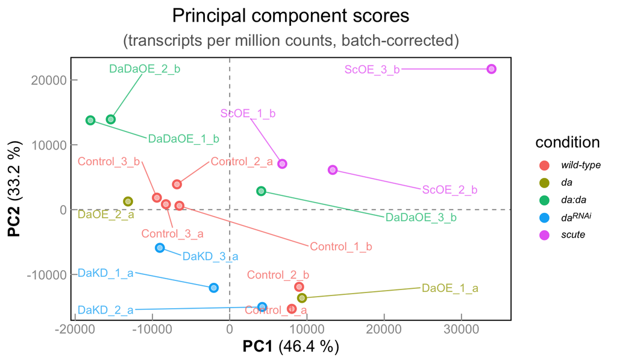

```r
xtitle <- paste0('**PC1** (', round(summary(pca)$importance['Proportion of Variance','PC1']*100,1), ' %)')
ytitle <- paste0('**PC2** (', round(summary(pca)$importance['Proportion of Variance','PC2']*100,1), ' %)')
ptitle <- 'Principal component scores'
stitle <- '(transcripts per million counts, batch-corrected)'

ggplot(scores,
       aes(x = PC1, y = PC2,
           label=factor(targets$sampleIDs),
           colour=factor(targets$condition_md) )
       ) +
  # data
  geom_vline(xintercept=0, linetype='dashed', colour='grey60', linewidth=0.5) +
  geom_hline(yintercept=0, linetype='dashed', colour='grey60', linewidth=0.5) +
  geom_point(size=4) +
  geom_point(size=2, colour='white', alpha=0.5) +
  geom_text_repel(size=4, alpha=0.75,
                  max.overlaps=Inf,
                  seed=42,
                  force=1.2, force_pull=-0.02,
                  box.padding=0.5, point.padding=0.5) +
  #lims(x= c(-115, 175), y = c(-70, 70)) +
  # decorations
  theme_minimal(base_size=16) +
  labs(x=xtitle,
       y=ytitle,
       title=ptitle,
       subtitle=stitle) +
  scale_colour_discrete(name="condition") +
  theme(legend.text = element_markdown(size=10),
        axis.title.x = element_markdown(),
        axis.title.y = element_markdown(),
        plot.title = element_text(hjust=0.5),
        plot.subtitle = element_text(hjust=0.5, color="grey40"),
        axis.text.x = element_text(color="grey60"),
        axis.text.y = element_text(color="grey60"),
        axis.ticks.x = element_line(linewidth=0.5, linetype = "solid", color="grey60"),
        axis.ticks.y = element_line(linewidth=0.5, linetype = "solid", color="grey60"),
        axis.ticks.length=unit(-0.25, "cm"),
        panel.border = element_rect(linewidth=1, linetype = "solid", fill = NA),
        panel.grid = element_blank())
```

### TPM _pseudo_counts with batch correction

If we do not reverse the transform:

```r
pca <- prcomp(t(tpm_log_bcorr), center=TRUE)
scores <- data.frame(targets$sampleIDs, pca$x[,1:2])
summary(pca)
```

```
## Importance of components:
##                            PC1     PC2      PC3      PC4     PC5     PC6
## Standard deviation     46.4034 24.6118 18.36186 11.28415 9.57964 8.16744
## Proportion of Variance  0.5991  0.1685  0.09381  0.03543 0.02553 0.01856
## Cumulative Proportion   0.5991  0.7677  0.86149  0.89692 0.92246 0.94102
##                            PC7    PC8    PC9    PC10    PC11    PC12    PC13
## Standard deviation     6.64060 6.3445 5.7194 4.81195 4.35333 3.96245 3.81643
## Proportion of Variance 0.01227 0.0112 0.0091 0.00644 0.00527 0.00437 0.00405
## Cumulative Proportion  0.95329 0.9645 0.9736 0.98003 0.98531 0.98968 0.99373
##                           PC14    PC15      PC16      PC17
## Standard deviation     3.52085 3.18473 4.547e-14 2.401e-14
## Proportion of Variance 0.00345 0.00282 0.000e+00 0.000e+00
## Cumulative Proportion  0.99718 1.00000 1.000e+00 1.000e+00
```

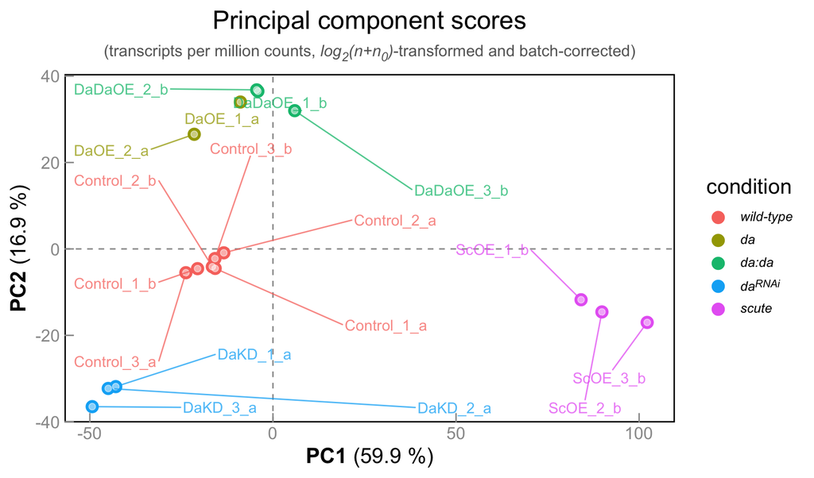

```r
xtitle <- paste0('**PC1** (', round(summary(pca)$importance['Proportion of Variance','PC1']*100,1), ' %)')
ytitle <- paste0('**PC2** (', round(summary(pca)$importance['Proportion of Variance','PC2']*100,1), ' %)')
ptitle <- 'Principal component scores'
stitle <- '(transcripts per million counts, *log~2~(n+n~0~)*-transformed and batch-corrected)'

ggplot(scores,
       aes(x = PC1, y = PC2,
           label=factor(targets$sampleIDs),
           colour=factor(targets$condition_md) )
       ) +
  # data
  geom_vline(xintercept=0, linetype='dashed', colour='grey60', linewidth=0.5) +
  geom_hline(yintercept=0, linetype='dashed', colour='grey60', linewidth=0.5) +
  geom_point(size=4) +
  geom_point(size=2, colour='white', alpha=0.5) +
  geom_text_repel(size=4, alpha=0.75,
                  max.overlaps=Inf,
                  seed=42,
                  force=1.2, force_pull=-0.02,
                  box.padding=0.5, point.padding=0.5) +
  #lims(x= c(-115, 175), y = c(-70, 70)) +
  # decorations
  theme_minimal(base_size=16) +
  labs(x=xtitle,
       y=ytitle,
       title=ptitle,
       subtitle=stitle) +
  scale_colour_discrete(name="condition") +
  theme(legend.text = element_markdown(size=10),
        axis.title.x = element_markdown(),
        axis.title.y = element_markdown(),
        plot.title = element_text(hjust=0.5),
        plot.subtitle = element_markdown(size=12, hjust=0.5, color="grey40"),
        axis.text.x = element_text(color="grey60"),
        axis.text.y = element_text(color="grey60"),
        axis.ticks.x = element_line(linewidth=0.5, linetype = "solid", color="grey60"),
        axis.ticks.y = element_line(linewidth=0.5, linetype = "solid", color="grey60"),
        axis.ticks.length=unit(-0.25, "cm"),
        panel.border = element_rect(linewidth=1, linetype = "solid", fill = NA),
        panel.grid = element_blank())
```

Quite similar. So I will stick to the `vst`-transformed pseudocounts for the paper.